[figure not shown]

Лабораторная работа №8

Настройка сетевых сервисов.DHCP

Сахно Никит Вячеславович

Российский университет дружбы народов, Москва, Россия

[figure not shown]

Вводная часть

Цель работы

Приобрести практические навыки по настройке динамического распределения IP-адресов

посредством протокола DHCP (Dynamic Host Configuration Protocol) в локальной сети.

Задание

1. Добавить DNS-записи для домена donskaya.rudn.ru на сервер dns.

2. Настроить DHCP-сервис на маршрутизаторе.

3. Заменить в конфигурации оконечных устройствах статическое распределение

адресов на динамическое.

4. При выполнении работы необходимо учитывать соглашение об именовании.

[figure not shown]

Выполнение лабораторной работы

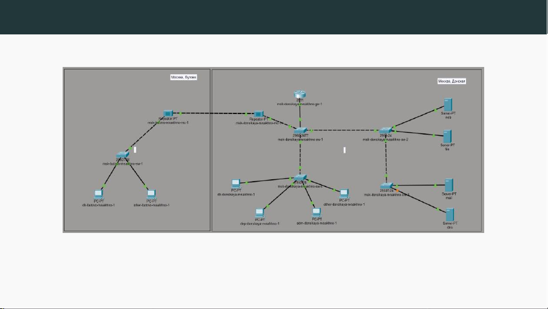

Выполнение лабораторной работы

Рис. 1: Логическая схема локальной сети с добавленным DNS-сервером

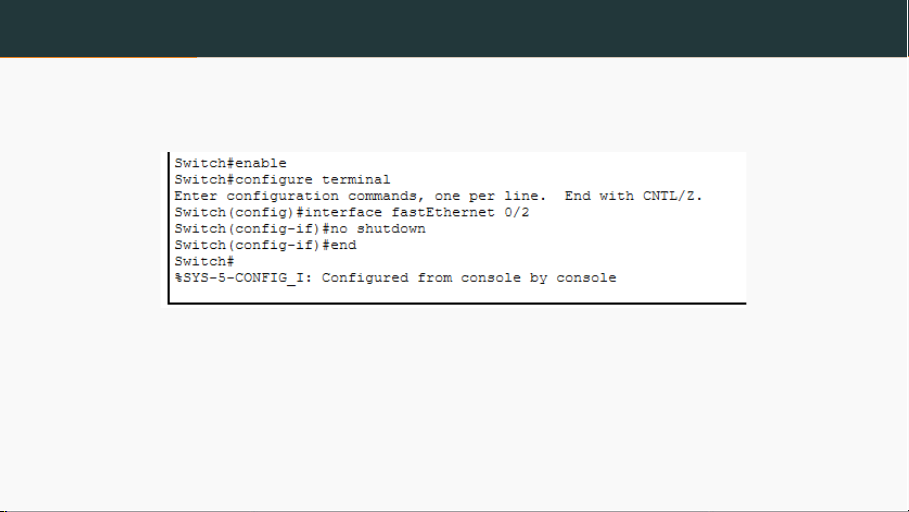

Выполнение лабораторной работы

Рис. 2: Активация порта

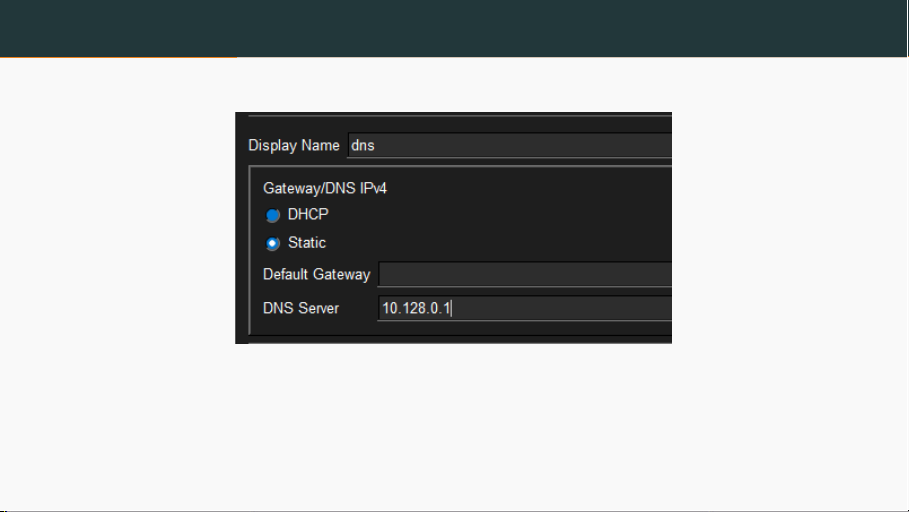

Выполнение лабораторной работы

Рис. 3: Конфигурация dns-сервера

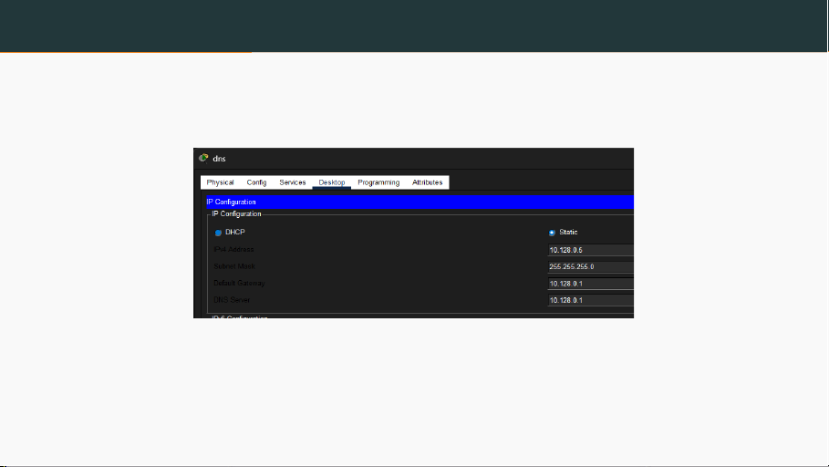

Выполнение лабораторной работы

Рис. 4: Конфигурация dns-сервера

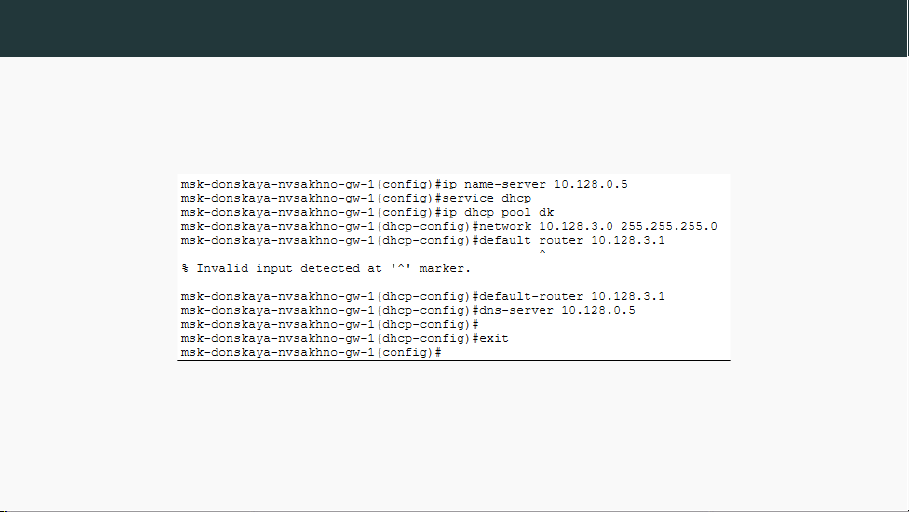

Выполнение лабораторной работы.

[figure not shown]

Выполнение лабораторной работы

Таблица 1: Регламент выделения ip-адресов (для сети класса C) {#tbl:reg}

IP-адреса Назначение

1

2–19

20–29

30–199

200–219

220–229

230–254

Шлюз

Сетевое оборудование

Серверы

Компьютеры, DHCP

Компьютеры, Static

Принтеры

Резерв

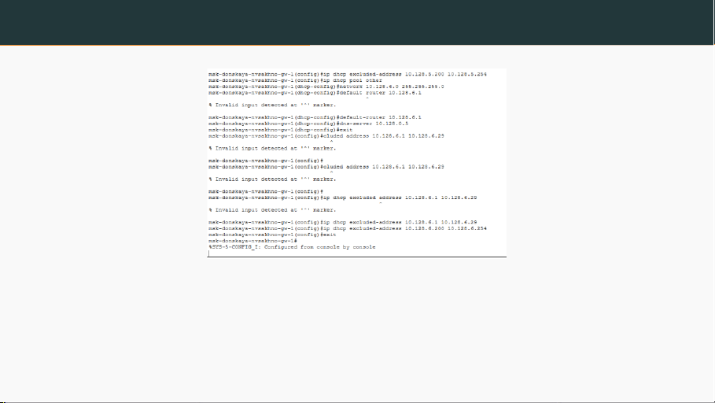

Выполнение лабораторной работы

Рис. 6: Настройка DHCP-сервис на маршрутизаторе

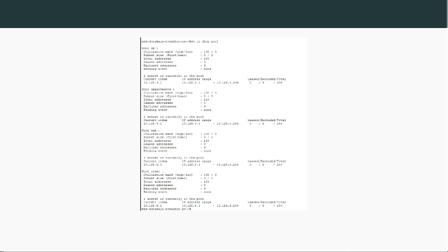

Выполнение лабораторной работы

Рис. 8: Информация о пулах DHCP

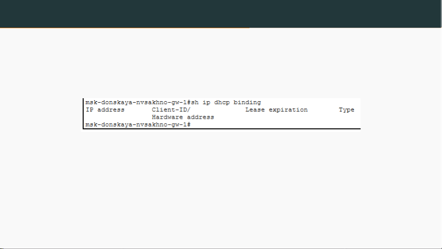

Выполнение лабораторной работы

Рис. 9: Информация о привязках выданных адресов

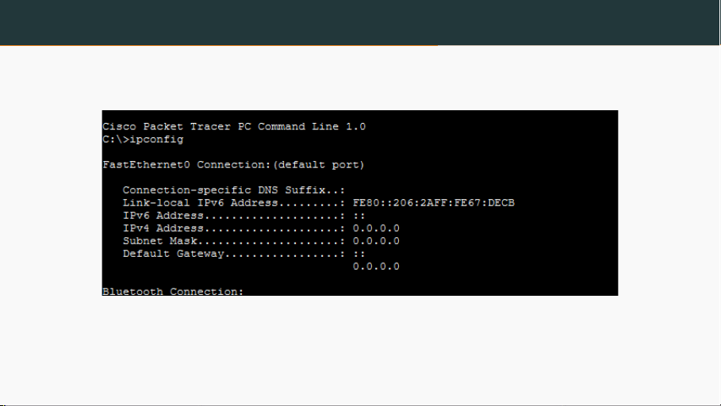

Выполнение лабораторной работы

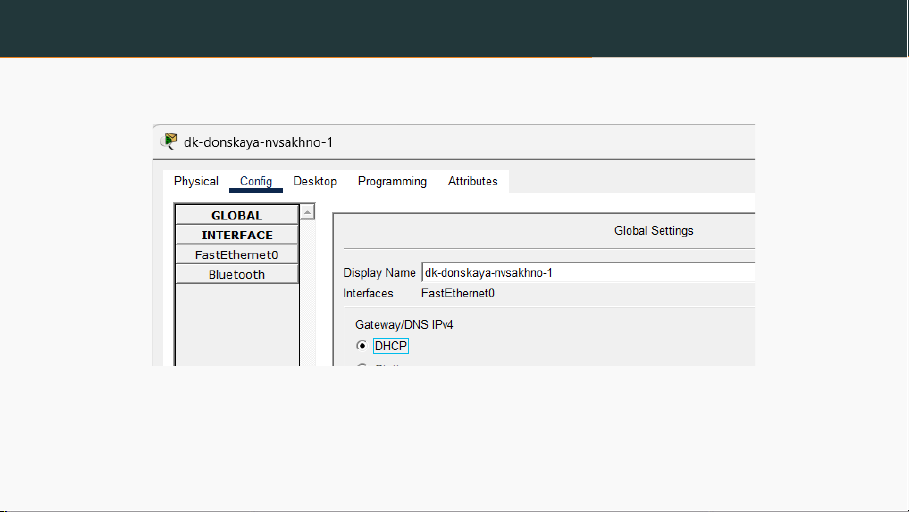

Выполнение лабораторной работы

Рис. 11: Замена в настройках статического распределения адресов на динамическое

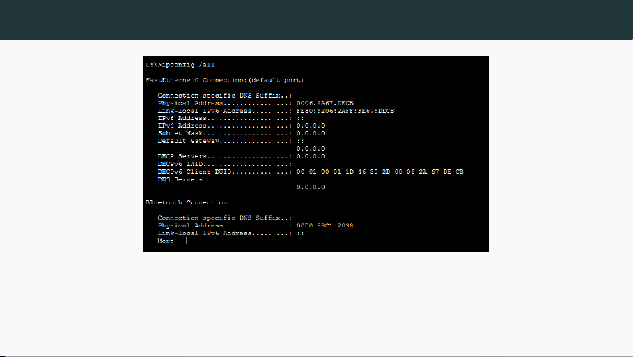

Выполнение лабораторной работы

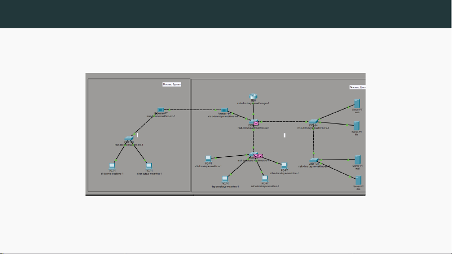

Выполнение лабораторной работы

Рис. 15: Запрос адреса по протоколу DHCP в режиме симуляции

[figure not shown]

Выводы

[figure not shown]

Выводы

В процессе выполнения данной лабораторной работы я приобрел практические навыки

по настройке динамического распределения IP-адресов посредством протокола DHCP

(Dynamic Host Configuration Protocol) в локальной сети.